# Assignment II

February 4, 2019

> Please submit your answers by 5.59 pm Monday February 4, 2019. Remember to show your work. In other words, always use echo=TRUE for the R code chunks that you provide. NOTE - All plots must show proper title, axis lables, and any legends used. Points will be deducted otherwise. Submissions must be made in HTML. Problem 6 has an additional submission to be made in DOCX or PDF format.

##### Initialization

```r
# Use this space to call any libraries here
rm(list=ls())
library(plyr)
library(dplyr)
library(lubridate)
library(grid)
library(ggplot2)
```

##### Section 1: Plotting

Q1) In Lecture 3, we worked with two datasets: “case_patients.csv” and “control_patients.csv” (under Files -> lectures -> lecture_3). We will use those files again in this question.

1. Plot a box plot of LOS ~ outcome for the whole cohort. You will have to combine case and control into a single dataset with the outcome for this purpose (as shown in the lecture notes). Write down any observations.

Ans.

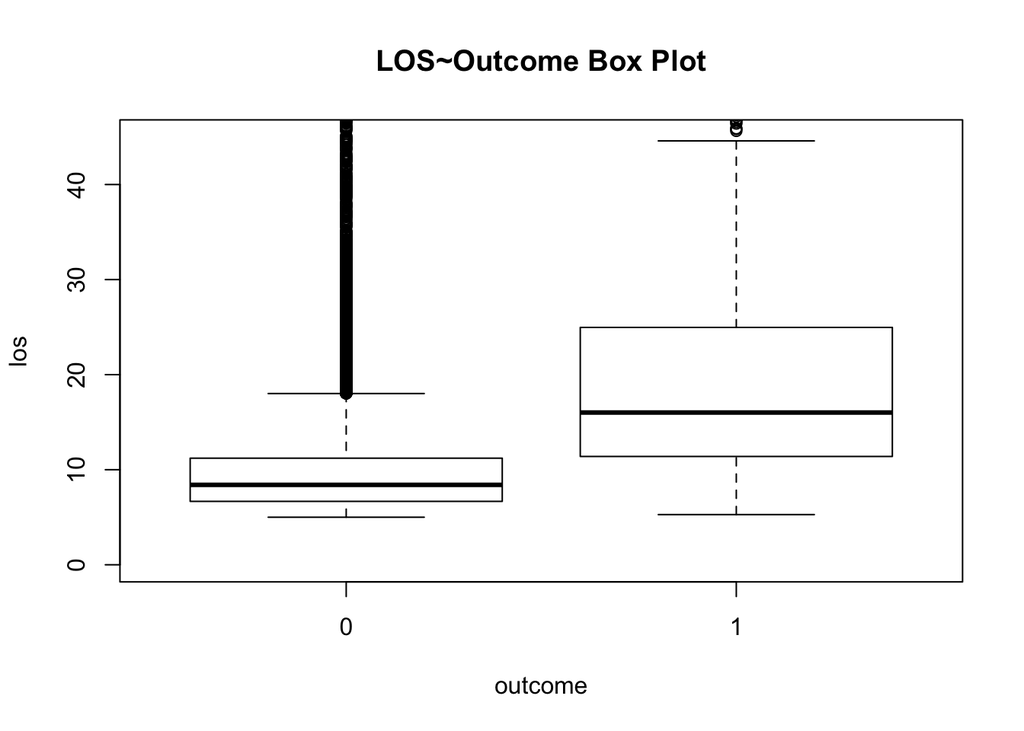

```r
# Insert code below
#read in datasets
d1_case <- read.csv("case_patients.csv", header = TRUE)
d2_control <- read.csv("control_patients.csv", header = TRUE)

#add columns for outcome: 1 = case, 0 = control
d1_case$outcome <- rep(1,nrow(d1_case))
d2_control$outcome <- rep(0, nrow(d2_control))

#combine both datasets into a single dataset
combined_data <- full_join(d1_case,d2_control)

#create a boxplot of LOS ~ outcome
attach(combined_data)
boxplot(los~outcome, main="LOS~Outcome Box Plot",xlab="outcome", ylab="los",ylim = c(0,45))
```

```r
#Observations
cat("Mean LOS for control",mean(d2_control$los), "\n")
```

```
## Mean LOS for control 10.40922
```

```r
cat("Mean LOS for case",mean(d1_case$los), "\n")
```

```
## Mean LOS for case 20.60876
```

```r
#Outliers in length of stay for the control made the boxplot difficult to compare data. Trimmed down the y-axis to 0-45 days to see distribution. The average LOS for case patients is ~21 days, while the average LOS for control patients is ~10 days. Ideally, this makes sense that case patients would stay in the hospital for a longer duration.
```

2. Plot a box plot of LOS ~ gender for the two groups in separate graphs. Write down any observations.

Ans.

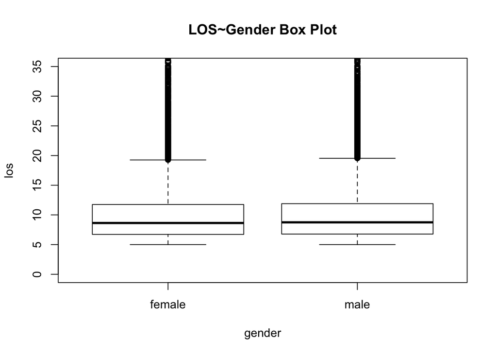

```r
# Insert code below

#create a boxplot of LOS ~ gender

attach(combined_data)
boxplot(los~gender, main="LOS~Gender Box Plot",xlab="gender", ylab="los", ylim = c(0,35))
```

```r
males <- combined_data[which(combined_data$gender == 'male'),]
females <- combined_data[which(combined_data$gender == 'female'),]

summary(males)
```

```
##   patient.ids       gender           age             los
##  Min.   :    3   female:    0   Min.   :20.00   Min.   :  5.000
##  1st Qu.: 6000   male  :15451   1st Qu.:31.00   1st Qu.:  6.776
##  Median :12087                  Median :44.00   Median :  8.750
##  Mean   :12066                  Mean   :43.09   Mean   : 11.054
##  3rd Qu.:18110                  3rd Qu.:55.00   3rd Qu.: 11.897
##  Max.   :24116                  Max.   :65.00   Max.   :406.102
##     outcome
##  Min.   :0.00000
##  1st Qu.:0.00000
##  Median :0.00000
##  Mean   :0.06388
##  3rd Qu.:0.00000
##  Max.   :1.00000
```

```r
summary(females)
```

```
##   patient.ids       gender          age             los
##  Min.   :    1   female:9972   Min.   :20.00   Min.   :  5.000
##  1st Qu.: 6067   male  :   0   1st Qu.:31.00   1st Qu.:  6.721
##  Median :11952                 Median :43.00   Median :  8.637
##  Mean   :12034                 Mean   :42.91   Mean   : 10.756
##  3rd Qu.:18049                 3rd Qu.:54.00   3rd Qu.: 11.750
##  Max.   :24119                 Max.   :65.00   Max.   :133.457
##     outcome
##  Min.   :0.00000
##  1st Qu.:0.00000
##  Median :0.00000
##  Mean   :0.03299
##  3rd Qu.:0.00000
##  Max.   :1.00000
```

```r
#observations? Outliers in length of stay in the male column makes the boxplot difficult to compare data. Trimmed down the y-axis to 0-35 days to see distribution. The average length of stay for males and females was ~11 days.
```

##### Section 2: Odds and odds ratios calculation

Q2) In a case-cohort study of 2000 patients studying renal disease caused by smoking, a group found the following numbers.  
1. A total of 300 patients suffered renal disease  
2. A total of 1000 patients were smokers  
3. Two-thirds of the patients who suffered renal disease smoked.

1. Identify the primary exposure and outcome of interest.

Ans. outcome = patients with renal disease, exposure = smoking (patients with renal disease ~ smoking)

2. Complete the below 2x2 table of exposure (on row) against outcome (on column).

Ans.

| Table | Renal Disease | No Renal Disease | Total |
| --- | --- | --- | --- |
| Smokers | 200 | 800 | 1000 |
| Non-smokers | 100 | 900 | 1000 |
| Total | 300 | 1700 | 2000 |

3. Calculate the odds ratio of incidence of renal disease among smokers.

Ans.

OR (case: renal disease among smokers) = 200/100 = 2 OR (control: no renal disease among non-smokeres) = 8/9 OR = case/control = 2/(8/9) = 18/8 = 2.25

Q3) Answer the following:

1. Suppose that an individual has a 18% chance of defaulting on their credit card payment. What are the odds that this individual will default?

Ans.

p(x) = 0.18 1- p(x) = 1 - 0.18 = 0.82 Odds = p(x) / (1-p(x) = 0.18/0.82 = 0.219 ~ 22%

2. On average, what fraction of people with an odds of 0.4 of defaulting on their credit card payment will actually default?

Ans.

OR = case/control odds = p(x)/(1-p(x)) 0.4 = p(x)/(1-p(x)) rearrange equation: 0.4 = 1.4p(x) p(x) = 0.4/1.4 = 0.285 ~ 0.29

##### Section 3: Study design

Q4) A hospital H noticed that approximately 10% of patients who underwent a particularly surgery (surgery S) also developed infection during their post-surgery recovery period. For surgery S, the post-surgery recovery period is 2 weeks. It is suspected a majority of these patients (about 60%) may have taken a particular antibiotic (ABX) during a 3-month period prior to the surgery. ABX could kill the “good” bacteria in the patients body causing the patient to be prone to infection after the surgery.

1. What is the outcome of interest and the exposure of interest in this study?

Ans. - outcome = Develop post-surgery infection - exposure = Took antibiotic ABX 3 months prior to surgery (patients that develop post-surgery infection ~ took antibiotic ABX 3 months prior to surgery)

2. Design a matched case-control study (matched on age and gender) that will allow a researcher to test this hypothesis. Identify inclusion and exclusion criteria.

Ans. 1) outcome = Develop post-surgery infection (Y/N) 2) exposure = Took antibiotic ABX 3 months prior to surgery S (Y/N) 3) inclusion criteria: took ABX <= 3 months, LOS post-surgery <= 2 weeks, age >= 18, include equal numbers of both genders (M/F) 4) exclusion criteria: not taking ABX at all and taking ABX > 3 months, LOS > 2 weeks, age < 18

3. Design a retrospective cohort study that will allow a researcher to test this hypothesis. Identify inclusion and exclusion criteria.

Ans. 1) exposure = Took ABX 3 months prior to having surgery S (Y/N) 2) outcome = Developed post-surgery infection (Y/N) 3) inclusion criteria: took ABX <= 3 months, LOS <= 2 weeks, age >= 18, include equal numbers of both genders (M/F), obtain patient data from “x” years prior 4) exclusion criteria: not taking ABX at all and taking ABX > 3 months, LOS > 2 weeks, age < 18

4. Design a prospective cohort study that will allow a researcher to test this hypothesis. Identify inclusion and exclusion criteria.

Prospective cohort study will be a study following a group of patients over a period of time. The researcher will select patients undergoing surger S. From these patients, the researcher will observe which patients have been expose to a full course of ABX within 3 months of the surgery.

Ans. 1) outcome = Develop post-surgery infection after surgery S. (Y/N) 2) exposure = Full course of ABX within 3 months. (Y/N) 3) inclusion criteria: will have surgery S, LOS <= 2 weeks, age >= 18, include equal numbers of both genders (M/F) 4) exclusion criteria: LOS > 2 weeks, age < 18

##### Section 4 : Creating Table 1.

Q5) Creating a Table 1: Under Assignments -> Assignment_II, read in the file called “smokedata.csv”. The codebook is as follows:

. ID: Unique numeric identifier  
. quit: 0= did not quit smoking in previous 12 months, 1= quit smoking in previous 12 months  
. advice 0= reported ‘did not receive advice from healthcare provider regarding quitting smoking.’, 1= reported ‘did receive advice…’  
. ill 0= no major illness diagnosed in previous 12 months, 1= major illness diagnosed in previous 12 months  
. sex 0=male, 1=female  
. educ 0= less than 12 years, 1= 12 years or more  
. provtype 0= Physician, 1= Nurse Practitioner  
. birth_yr Four digit year of patient’s birth  
. app_yr Four digit year of patient’s appointment  
. age_at_app* Patient’s age at the appointment.

*For simplicity, we will assume all patients have already had their birthday when they attend their appointment. Therefore, age should equal app_yr – birth_yr.

The objective of the study behind the dataset was to determine the association between of providing smoking cessation advice to patients and whether they quit smoking during the same time period.

Complete the attached Table 1 (Problem6_Table1.docx) and upload it into Canvas (you can upload either .docx or .pdf). Use the space below to show your work.

```r
# Insert code below
smoke_data <- read.csv("smokedata.csv", header = TRUE)

#Clean up data: NA non-binary values and birth_yr

smoke_data <- smoke_data[!(smoke_data$quit!="1" & smoke_data$quit!="0"),]
smoke_data <- smoke_data[!(smoke_data$birth_yr<1912 | smoke_data$birth_yr>2005),]
smoke_data <- smoke_data[!(smoke_data$age_at_appt<18 | smoke_data$age_at_appt>100),]
smoke_data <- smoke_data[!(smoke_data$appt_yr!="2012"),]

summary(smoke_data)
```

```
##        id             quit            advice            ill
##  Min.   :  1.0   Min.   :0.0000   Min.   :0.0000   Min.   :0.0000
##  1st Qu.: 70.5   1st Qu.:0.0000   1st Qu.:0.0000   1st Qu.:0.0000
##  Median :125.5   Median :0.0000   Median :0.0000   Median :0.0000
##  Mean   :124.3   Mean   :0.2371   Mean   :0.2371   Mean   :0.1598
##  3rd Qu.:182.8   3rd Qu.:0.0000   3rd Qu.:0.0000   3rd Qu.:0.0000
##  Max.   :240.0   Max.   :1.0000   Max.   :1.0000   Max.   :1.0000
##       sex              educ           provtype          birth_yr
##  Min.   :0.0000   Min.   :0.0000   Min.   :0.00000   Min.   :1924
##  1st Qu.:0.0000   1st Qu.:0.0000   1st Qu.:0.00000   1st Qu.:1946
##  Median :1.0000   Median :1.0000   Median :0.00000   Median :1960
##  Mean   :0.5258   Mean   :0.5206   Mean   :0.09278   Mean   :1962
##  3rd Qu.:1.0000   3rd Qu.:1.0000   3rd Qu.:0.00000   3rd Qu.:1976
##  Max.   :1.0000   Max.   :1.0000   Max.   :1.00000   Max.   :1994
##     appt_yr      age_at_appt
##  Min.   :2012   Min.   :18.00
##  1st Qu.:2012   1st Qu.:36.00
##  Median :2012   Median :52.50
##  Mean   :2012   Mean   :50.25
##  3rd Qu.:2012   3rd Qu.:66.00
##  Max.   :2012   Max.   :88.00
```

```r
#TOTAL Quitter and Non-Quitters
d.total_non_quitter <- smoke_data[which(smoke_data$quit == "0"),]
nrow(d.total_non_quitter)
```

```
## [1] 148
```

```r
d.total_quitter <- smoke_data[which(smoke_data$quit == "1"),]
nrow(d.total_quitter)
```

```
## [1] 46
```

```r
#Find Count, Percentage, and p-value for Age and mean(SD) in years for Non-Quitters vs. Quitters

cat("Mean age for Non-Quitters",mean(d.total_non_quitter$age_at_appt), "\n")
```

```
## Mean age for Non-Quitters 51.32432
```

```r
cat("Std for age for Non-Quitters",sd(d.total_non_quitter$age_at_appt), "\n")
```

```
## Std for age for Non-Quitters 16.86853
```

```r
cat("Mean age for Quitters",mean(d.total_quitter$age_at_appt), "\n")
```

```
## Mean age for Quitters 46.78261
```

```r
cat("Std for age for Quitters",sd(d.total_quitter$age_at_appt), "\n")
```

```
## Std for age for Quitters 18.3508
```

```r
t.test(d.total_non_quitter$age_at_appt, d.total_quitter$age_at_appt)
```

```
##
##  Welch Two Sample t-test
##
## data:  d.total_non_quitter$age_at_appt and d.total_quitter$age_at_appt
## t = 1.4938, df = 70.257, p-value = 0.1397
## alternative hypothesis: true difference in means is not equal to 0
## 95 percent confidence interval:
##  -1.521543 10.604974
## sample estimates:
## mean of x mean of y
##  51.32432  46.78261
```

```r
#Make a 2x2 table for quit vs. sex
gender_table <- with(smoke_data,table(quit,sex))
print(gender_table)
```

```
##     sex
## quit  0  1
##    0 68 80
##    1 24 22
```

```r
#Percentage and p-value for gender in Non-quitters vs. Quitters
print(gender_table/nrow(smoke_data)*100)
```

```
##     sex
## quit        0        1
##    0 35.05155 41.23711
##    1 12.37113 11.34021
```

```r
chisq.test(gender_table)
```

```
##
##  Pearson's Chi-squared test with Yates' continuity correction
##
## data:  gender_table
## X-squared = 0.32471, df = 1, p-value = 0.5688
```

```r
#Make a 2x2 table for quit vs. major illness
majorill_table <- with(smoke_data,table(quit,ill))
print(majorill_table)
```

```
##     ill
## quit   0   1
##    0 130  18
##    1  33  13
```

```r
#Find Percentage and p-value for Major Illness in Non-Quitters vs. Quitters
print(majorill_table/nrow(smoke_data)*100)
```

```
##     ill
## quit         0         1
##    0 67.010309  9.278351
##    1 17.010309  6.701031
```

```r
chisq.test(majorill_table)
```

```
##
##  Pearson's Chi-squared test with Yates' continuity correction
##
## data:  majorill_table
## X-squared = 5.6281, df = 1, p-value = 0.01767
```

```r
#Make a 2x2 Table for quit vs. educ
educ_table <- with(smoke_data,table(quit,educ))
print(educ_table)
```

```
##     educ
## quit  0  1
##    0 68 80
##    1 25 21
```

```r
#Find Percentage and p-value among <12yo and >12yo in Non-Quitters vs. Quitters
print(educ_table/nrow(smoke_data)*100)
```

```
##     educ
## quit        0        1
##    0 35.05155 41.23711
##    1 12.88660 10.82474
```

```r
chisq.test(educ_table)
```

```
##
##  Pearson's Chi-squared test with Yates' continuity correction
##
## data:  educ_table
## X-squared = 0.68449, df = 1, p-value = 0.408
```

```r
#Make a 2x2 Table for quit vs. smoking advice
advice_table <- with(smoke_data,table(quit,advice))
print(advice_table)
```

```
##     advice
## quit   0   1
##    0 126  22
##    1  22  24
```

```r
#Find Percentage and p-value for Smoking Advice in Non-Quitters vs. Quitters
print(advice_table/nrow(smoke_data)*100)
```

```
##     advice
## quit        0        1
##    0 64.94845 11.34021
##    1 11.34021 12.37113
```

```r
chisq.test(advice_table)
```

```
##
##  Pearson's Chi-squared test with Yates' continuity correction
##
## data:  advice_table
## X-squared = 24.981, df = 1, p-value = 5.79e-07
```

```r
#Make a 2x2 Table for quit vs. provider type
provider_table <- with(smoke_data,table(quit,provtype))
print(provider_table)
```

```
##     provtype
## quit   0   1
##    0 134  14
##    1  42   4
```

```r
#Find Percentage and p-value for Provider Type in Non-Quitters vs. Quitters
print(provider_table/nrow(smoke_data)*100)
```

```
##     provtype
## quit         0         1
##    0 69.072165  7.216495
##    1 21.649485  2.061856
```

```r
chisq.test(provider_table)
```

```
##
##  Pearson's Chi-squared test with Yates' continuity correction
##
## data:  provider_table
## X-squared = 7.9064e-31, df = 1, p-value = 1
```